# PBIO 294 Final Exam

Jeremy Weiland

12/12/2017

Below are the three questions for the PBIO 294 Final Exam. All work must be your own. Reference to outside sources should be limited to the documentation for R, Stan, JAGS, or general questions regarding pdf’s, etc. This exam is due by midnight, Monday, 11 Dec 2017. 20% will be deducted for each additonal 6 hours that this exam is turned in late. Please email your R/.Rmd file to brian.beckage@uvm.edu.

1. (30 points) An ecologist is interested in the intermediate disturbance hypothesis (IDH) that postulates that the highest species richness should be found at intermediate levels of disturbance. Write a likelihood function to estimate the  
   parameters for a quadratic regression models given in Beckage and Stout 2000 (http://www.uvm.edu/~bbeckage/Manuscripts/BeckageStout.corrected.2000.jvs.pdf), but assuming a Poisson likelihood with a log link function. Provide your i. *likelihood function and supporting R code for finding the MLE’s*, ii. a *plot of the data with the fitted line* and iii. report the *regression parameters (bo, b1, and b2)*, and iv. the value of the *negative log likelihood at the MLEs*. Note: You must write your own likelihood function and not use a built in R function or package, e.g, lm, glm, etc.

The data may be read using:

```r
srDat<-read.table("http://www.uvm.edu/~bbeckage/Teaching/PBIO_294/Data/idh.csv",sep=',',header=TRUE)

#i) Likelihood functions
nllPoi = function(parVec, nFires, sr){
  b0 = parVec[1]
  b1 = parVec[2]
  b2 = parVec[3]

  srPred = b2*nFires^2+b1*nFires+b0
  nllik = -sum(dpois(x=sr, lambda=srPred, log=TRUE))
  return(nllik)
}

parVec = c(1, 1, 1) # Initial parameter values

outPois = optim(par=parVec,
                fn=nllPoi,
                method="BFGS",
                nFires=srDat$nFires,
                sr=srDat$sr)
```

[output not shown]

```r
outPois$par
```

```
## [1]  6.1554232  6.4340482 -0.6540371
```

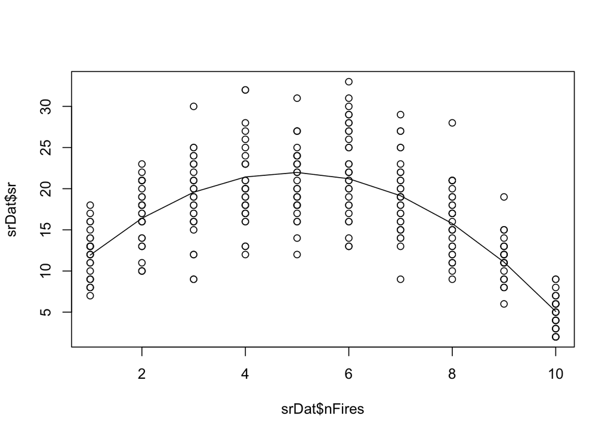

```r
#ii) plots
firePred = srDat$nFires[order(srDat$nFires)]

y = outPois$par[3]*srDat$nFires^2 + outPois$par[2]*srDat$nFires + outPois$par[1]
plot(srDat$nFires, srDat$sr)
lines(firePred, y)
```

```r
#iii) regression parameters
b0 = outPois$par[1]
b1 = outPois$par[2]
b2 = outPois$par[3]

b0
```

```
## [1] 6.155423
```

```r
b1
```

```
## [1] 6.434048
```

```r
b2
```

```
## [1] -0.6540371
```

```r
#iv) negative log likelihood
nll = nllPoi(c(b0,b1,b2), srDat$nFires, srDat$sr)
nll
```

```
## [1] 830.6317
```

2. (30 points) Repeat exercise 1 except now fitting the model using either Rstan or Rjags. You must write your own Stan/JAGS model, meaning that you can not use one of the Stan helper libraries such as the brms or rstanarm libraries. Provide your i. *Stan/JAGS model code and supporting R code for running the Stan/JAGS model*, ii. report the *2.5%, 50%, and 97.5% percentiles for the regression parameters (bo, b1, and b2)*, iii. *plot the posterior distributions for each of these parameters* and iv. *assess the convergence of your chains using the Gelman-Rubin statistic.*

```r
#i) JAGS model code
modelString<-"
model {
  for (i in 1:N){
    sr[i] ~ dpois(lam.hat[i])
    lam.hat[i] = beta0 + beta1*nFires[i] + beta2*nFires[i]^2
  }

  beta0 ~ dnorm(0, .0001)
  beta1 ~ dnorm(0, .0001)
  beta2 ~ dnorm(0, .0001)
}
"
writeLines(modelString, con='poissonReg.jags.txt')

library(rjags)
jags <- jags.model('poissonReg.jags.txt',
                   data = list('nFires' = srDat$nFires,
                               'sr' = srDat$sr,
                               'N' = length(srDat$sr)),
                   inits = list(
                       list('beta0'=1,'beta1'=2),
                       list('beta0'=1,'beta1'=.2),
                       list('beta0'=.1,'beta1'=2),
                       list('beta0'=2,'beta1'=5)),
                   n.chains = 4,
                   n.adapt = 100)
update(jags, 1000)

jags.samples(jags,
             c('beta0', 'beta1', 'beta2'),
             10000)
```

```
## $beta0
## mcarray:
## [1] 6.098943
##
## Marginalizing over: iteration(10000),chain(4)
##
## $beta1
## mcarray:
## [1] 6.466521
##
## Marginalizing over: iteration(10000),chain(4)
##
## $beta2
## mcarray:
## [1] -0.6567117
##
## Marginalizing over: iteration(10000),chain(4)
```

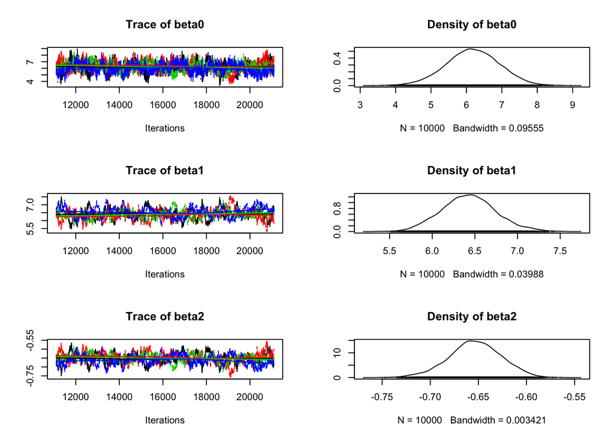

```r
library(coda)
codaSamples = coda.samples(jags, c('beta0','beta1', 'beta2'), 10000, 1)

plot(codaSamples, trace = TRUE, density = TRUE)
```

```r
#ii) summary statistics
summaryStats = data.frame(means = summary(codaSamples)$statistics[,1],
                          stdev = summary(codaSamples)$statistics[,2],
                          "2.5 percentiles" = summary(codaSamples)$quantiles[,1],
                          "50 percentiles" = summary(codaSamples)$quantiles[,3],
                          "97.5 percentiles" = summary(codaSamples)$quantiles[,5])

head(summaryStats)
```

```
##            means      stdev X2.5.percentiles X50.percentiles
## beta0  6.1775737 0.75170384         4.671237       6.1764551
## beta1  6.4283900 0.32046887         5.816615       6.4246699
## beta2 -0.6535107 0.02742065        -0.710549      -0.6533437
##       X97.5.percentiles
## beta0         7.6274790
## beta1         7.1006040
## beta2        -0.6011256
```

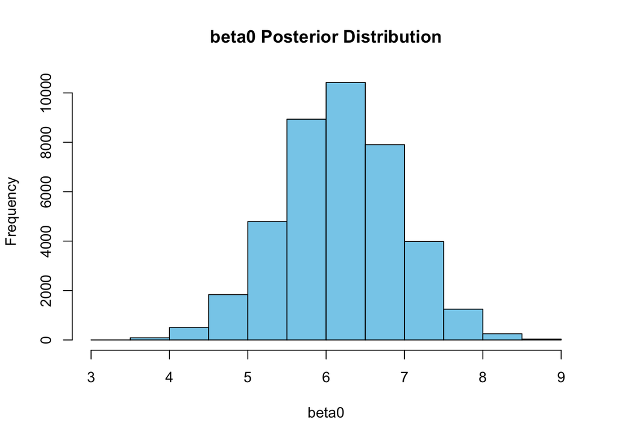

```r
#iii) posterior distributions
b0Chain = as.mcmc.list(codaSamples[,1])
b1Chain = as.mcmc.list(codaSamples[,2])
b2Chain = as.mcmc.list(codaSamples[,3])

hist(rowMeans(as.matrix(b0Chain)),
     col = "skyblue",
     main = "beta0 Posterior Distribution",
     xlab = "beta0")
```

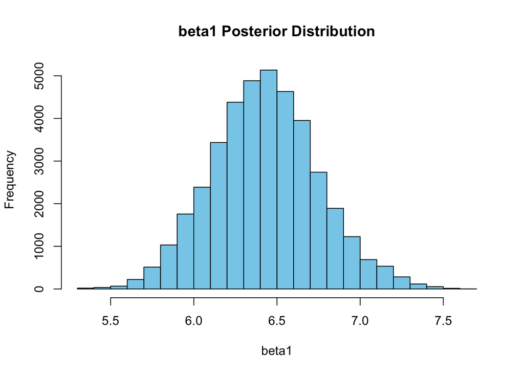

```r
hist(rowMeans(as.matrix(b1Chain)),
     col = "skyblue",
     main = "beta1 Posterior Distribution",
     xlab = "beta1")
```

[figure not shown]

```r
hist(rowMeans(as.matrix(b2Chain)),
     col = "skyblue",
     main = "beta1 Posterior Distribution",
     xlab = "beta1")
```

```r
#iv) gelman rubin statistics
b0GelRub = gelman.diag(b0Chain)
b1GelRub = gelman.diag(b1Chain)
b2GelRub = gelman.diag(b2Chain)

b0GelRub
```

```
## Potential scale reduction factors:
##
##      Point est. Upper C.I.
## [1,]       1.03       1.09
```

```r
b1GelRub
```

```
## Potential scale reduction factors:
##
##      Point est. Upper C.I.
## [1,]       1.05       1.13
```

```r
b2GelRub
```

```
## Potential scale reduction factors:
##
##      Point est. Upper C.I.
## [1,]       1.05       1.13
```

Fit this model using either Rstan or Rjags. You must write your own Stan/JAGS model, meaning that you can not use one of the Stan helper libraries such as the brms or rstanarm libraries. Provide your i. *Stan/JAGS model code and supporting R code for running the Stan/JAGS model*, ii. report the *2.5%, 50%, and 97.5% percentiles for the regression parameters (b1, b1, b2, b3, and b4)*, iii. *plot the posterior distributions for each of these parameters* and iv. *assess the convergence of your chains using the Gelman-Rubin statistic.*

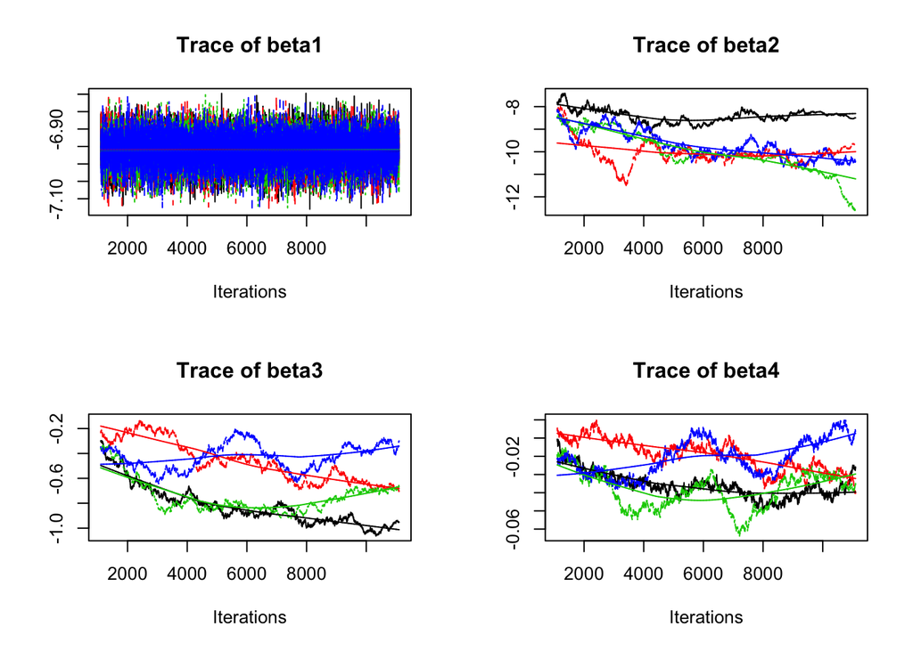

```r
require(rjags)
seeds<-read.table("http://www.uvm.edu/~bbeckage/Teaching/PBIO_294/Data/seeds.csv",sep=',',header=TRUE)
seedDat = list(seedSurv = seeds$seedLost,
               seedMass = sort(seeds$mass),
               canopyGap = seeds$gap,
               N = length(seeds$seedLost))

modelString3 = "
model{
  for(i in 1:N){
    seedSurv[i] ~ dbin(theta[i], N)
    logit(theta[i]) = beta0[i] + beta1*canopyGap[i]
    beta0[i] ~ dgamma(mu[i]^2/tau, mu[i]/tau)
    log(mu[i]) = beta2 + beta3*seedMass[i] - beta4*seedMass[i]^2
  }

  beta1 ~ dnorm(0, 0.001)
  beta2 ~ dnorm(0, 0.001)
  beta3 ~ dnorm(0, 0.001)
  beta4 ~ dnorm(0, 0.001)
  tau ~ dgamma(0.001, 0.001)
}
"
writeLines(modelString3, con='heriarch.jags.txt')

library(rjags)
jags <- jags.model('heriarch.jags.txt',
                   data = seedDat,
                   n.chains = 4,
                   n.adapt = 100)
update(jags, 1000)

# jags.samples(jags,
#              c('beta1', 'beta2', 'beta3', 'beta4'),
#              1000)

codaSamples = coda.samples(jags, c('beta1','beta2', 'beta3', 'beta4'), 10000, 1)

plot(codaSamples, trace = TRUE, density = FALSE)
```

```r
#ii) summmary statistics
summaryStats = data.frame(means = summary(codaSamples)$statistics[,1],
                          "2.5 percentiles" = summary(codaSamples)$quantiles[,1],
                          "50 percentiles" = summary(codaSamples)$quantiles[,3],
                          "97.5 percentiles" = summary(codaSamples)$quantiles[,5])

head(summaryStats)
```

```
##             means X2.5.percentiles X50.percentiles X97.5.percentiles
## beta1 -6.96119494      -7.05272944     -6.96052274       -6.87316597
## beta2 -9.54198338     -11.16251716     -9.77710662       -8.09439376
## beta3 -0.61694862      -0.98612054     -0.62622468       -0.21687422
## beta4 -0.02872611      -0.05159228     -0.02994253       -0.00600265
```

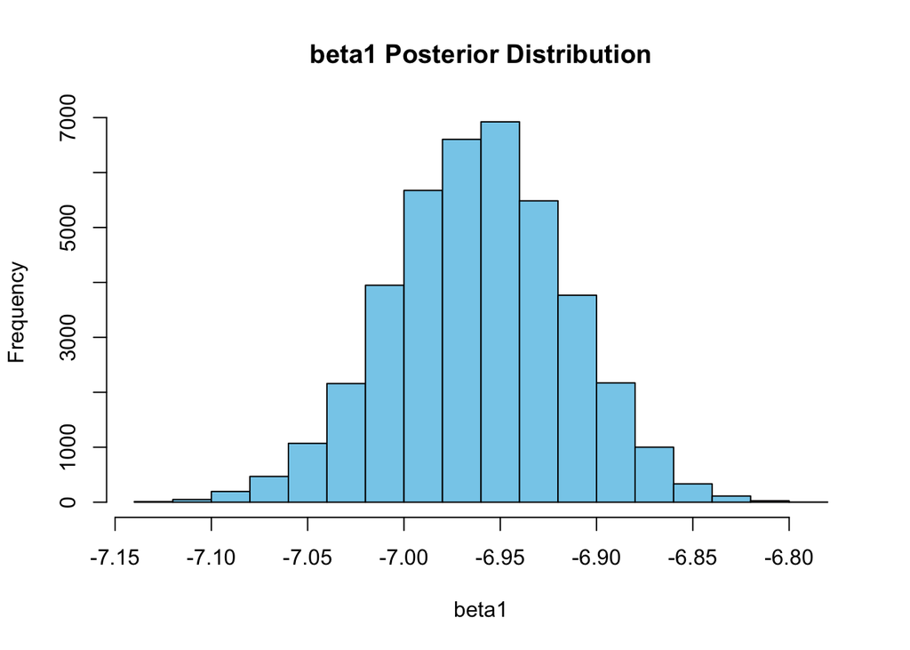

```r
#iii) posterior distributions
b1Chain = as.mcmc.list(codaSamples[,1])
b2Chain = as.mcmc.list(codaSamples[,2])
b3Chain = as.mcmc.list(codaSamples[,3])
b4Chain = as.mcmc.list(codaSamples[,4])

hist(rowMeans(as.matrix(b1Chain)),
     col = "skyblue",
     main = "beta1 Posterior Distribution",
     xlab = "beta1")
```

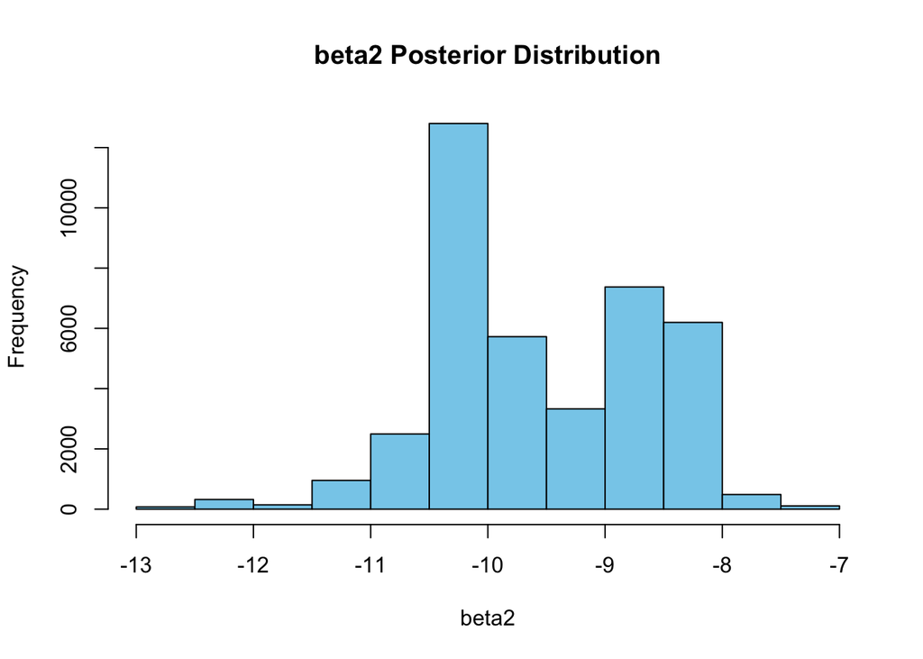

```r
hist(rowMeans(as.matrix(b2Chain)),
     col = "skyblue",
     main = "beta2 Posterior Distribution",
     xlab = "beta2")
```

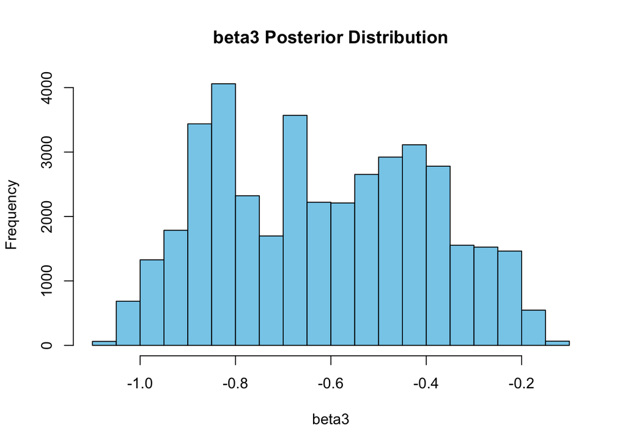

```r
hist(rowMeans(as.matrix(b3Chain)),
     col = "skyblue",
     main = "beta3 Posterior Distribution",
     xlab = "beta3")
```

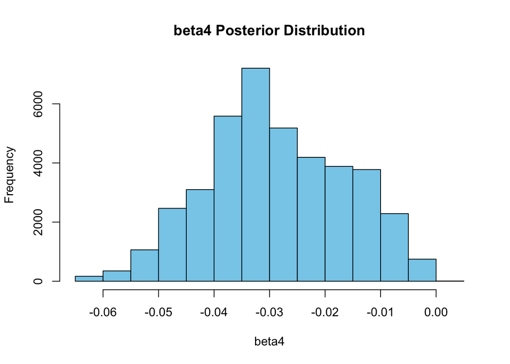

```r
hist(rowMeans(as.matrix(b4Chain)),
     col = "skyblue",
     main = "beta4 Posterior Distribution",
     xlab = "beta4")
```

```r
#iv) gelman rubin statistics
b1GelRub = gelman.diag(b1Chain)
b2GelRub = gelman.diag(b2Chain)
b3GelRub = gelman.diag(b3Chain)
b4GelRub = gelman.diag(b4Chain)

b1GelRub
```

```
## Potential scale reduction factors:
##
##      Point est. Upper C.I.
## [1,]          1          1
```

```r
b2GelRub
```

```
## Potential scale reduction factors:
##
##      Point est. Upper C.I.
## [1,]       3.49       8.56
```

```r
b3GelRub
```

```
## Potential scale reduction factors:
##
##      Point est. Upper C.I.
## [1,]       3.92       6.99
```

```r
b4GelRub
```

```
## Potential scale reduction factors:
##
##      Point est. Upper C.I.
## [1,]       2.23       3.77
```